# Diabetes dataset - SLR

Haley Egan

12/5/2021

```r
#clean data

library(faraway)
library(caret)
df <- diabetes

?diabetes
summary(df)
```

```
##        id             chol          stab.glu          hdl
##  Min.   : 1000   Min.   : 78.0   Min.   : 48.0   Min.   : 12.00
##  1st Qu.: 4792   1st Qu.:179.0   1st Qu.: 81.0   1st Qu.: 38.00
##  Median :15766   Median :204.0   Median : 89.0   Median : 46.00
##  Mean   :15978   Mean   :207.8   Mean   :106.7   Mean   : 50.45
##  3rd Qu.:20336   3rd Qu.:230.0   3rd Qu.:106.0   3rd Qu.: 59.00
##  Max.   :41756   Max.   :443.0   Max.   :385.0   Max.   :120.00
##                  NA's   :1                       NA's   :1
##      ratio            glyhb             location        age           gender
##  Min.   : 1.500   Min.   : 2.68   Buckingham:200   Min.   :19.00   male  :169
##  1st Qu.: 3.200   1st Qu.: 4.38   Louisa    :203   1st Qu.:34.00   female:234
##  Median : 4.200   Median : 4.84                    Median :45.00
##  Mean   : 4.522   Mean   : 5.59                    Mean   :46.85
##  3rd Qu.: 5.400   3rd Qu.: 5.60                    3rd Qu.:60.00
##  Max.   :19.300   Max.   :16.11                    Max.   :92.00
##  NA's   :1        NA's   :13
##      height          weight         frame         bp.1s           bp.1d
##  Min.   :52.00   Min.   : 99.0   small :104   Min.   : 90.0   Min.   : 48.00
##  1st Qu.:63.00   1st Qu.:151.0   medium:184   1st Qu.:121.2   1st Qu.: 75.00
##  Median :66.00   Median :172.5   large :103   Median :136.0   Median : 82.00
##  Mean   :66.02   Mean   :177.6   NA's  : 12   Mean   :136.9   Mean   : 83.32
##  3rd Qu.:69.00   3rd Qu.:200.0                3rd Qu.:146.8   3rd Qu.: 90.00
##  Max.   :76.00   Max.   :325.0                Max.   :250.0   Max.   :124.00
##  NA's   :5       NA's   :1                    NA's   :5       NA's   :5
##      bp.2s           bp.2d            waist           hip
##  Min.   :110.0   Min.   : 60.00   Min.   :26.0   Min.   :30.00
##  1st Qu.:138.0   1st Qu.: 84.00   1st Qu.:33.0   1st Qu.:39.00
##  Median :149.0   Median : 92.00   Median :37.0   Median :42.00
##  Mean   :152.4   Mean   : 92.52   Mean   :37.9   Mean   :43.04
##  3rd Qu.:161.0   3rd Qu.:100.00   3rd Qu.:41.0   3rd Qu.:46.00
##  Max.   :238.0   Max.   :124.00   Max.   :56.0   Max.   :64.00
##  NA's   :262     NA's   :262      NA's   :2      NA's   :2
##     time.ppn
##  Min.   :   5.0
##  1st Qu.:  90.0
##  Median : 240.0
##  Mean   : 341.2
##  3rd Qu.: 517.5
##  Max.   :1560.0
##  NA's   :3
```

```r
head(df)
```

```
##     id chol stab.glu hdl ratio glyhb   location age gender height weight  frame
## 1 1000  203       82  56   3.6  4.31 Buckingham  46 female     62    121 medium
## 2 1001  165       97  24   6.9  4.44 Buckingham  29 female     64    218  large
## 3 1002  228       92  37   6.2  4.64 Buckingham  58 female     61    256  large
## 4 1003   78       93  12   6.5  4.63 Buckingham  67   male     67    119  large
## 5 1005  249       90  28   8.9  7.72 Buckingham  64   male     68    183 medium
## 6 1008  248       94  69   3.6  4.81 Buckingham  34   male     71    190  large
##   bp.1s bp.1d bp.2s bp.2d waist hip time.ppn
## 1   118    59    NA    NA    29  38      720
## 2   112    68    NA    NA    46  48      360
## 3   190    92   185    92    49  57      180
## 4   110    50    NA    NA    33  38      480
## 5   138    80    NA    NA    44  41      300
## 6   132    86    NA    NA    36  42      195
```

```r
df <- subset(df, select = -c(id,bp.2s,bp.2d))

df <- df
df$glyhb[is.na(df$glyhb)] <- median(df$glyhb, na.rm = TRUE)

df <- df
df$chol[is.na(df$chol)] <- median(df$chol, na.rm = TRUE)

df <- df
df$hdl[is.na(df$hdl)] <- median(df$hdl, na.rm = TRUE)

df <- df
df$ratio[is.na(df$ratio)] <- median(df$ratio, na.rm = TRUE)

df <- df
df$height[is.na(df$height)] <- median(df$height, na.rm = TRUE)

df <- df
df$weight[is.na(df$weight)] <- median(df$weight, na.rm = TRUE)

df <- df
df$bp.1s[is.na(df$bp.1s)] <- median(df$bp.1s, na.rm = TRUE)

df <- df
df$bp.1d[is.na(df$bp.1d)] <- median(df$bp.1d, na.rm = TRUE)

df <- df
df$waist[is.na(df$waist)] <- median(df$waist, na.rm = TRUE)

df <- df
df$hip[is.na(df$hip)] <- median(df$hip, na.rm = TRUE)

df <- df
df$time.ppn[is.na(df$time.ppn)] <- median(df$time.ppn, na.rm = TRUE)

#df$frame <- df$frame %>% replace_na('medium')

head(df)
```

```
##   chol stab.glu hdl ratio glyhb   location age gender height weight  frame
## 1  203       82  56   3.6  4.31 Buckingham  46 female     62    121 medium
## 2  165       97  24   6.9  4.44 Buckingham  29 female     64    218  large
## 3  228       92  37   6.2  4.64 Buckingham  58 female     61    256  large
## 4   78       93  12   6.5  4.63 Buckingham  67   male     67    119  large
## 5  249       90  28   8.9  7.72 Buckingham  64   male     68    183 medium
## 6  248       94  69   3.6  4.81 Buckingham  34   male     71    190  large
##   bp.1s bp.1d waist hip time.ppn
## 1   118    59    29  38      720
## 2   112    68    46  48      360
## 3   190    92    49  57      180
## 4   110    50    33  38      480
## 5   138    80    44  41      300
## 6   132    86    36  42      195
```

```r
#summary(df)
```

#select two columns for Simple Linear Regression

```r
#make a new data frame with only glyhb and stab.glu
SLRdf <- df[,c('stab.glu', 'glyhb')]
head(SLRdf)
```

```
##   stab.glu glyhb
## 1       82  4.31
## 2       97  4.44
## 3       92  4.64
## 4       93  4.63
## 5       90  7.72
## 6       94  4.81
```

Response Variable = glyhb (Glycosolated Hemoglobin) Predictor Variable = stab.glu (Stabilized Glucose)

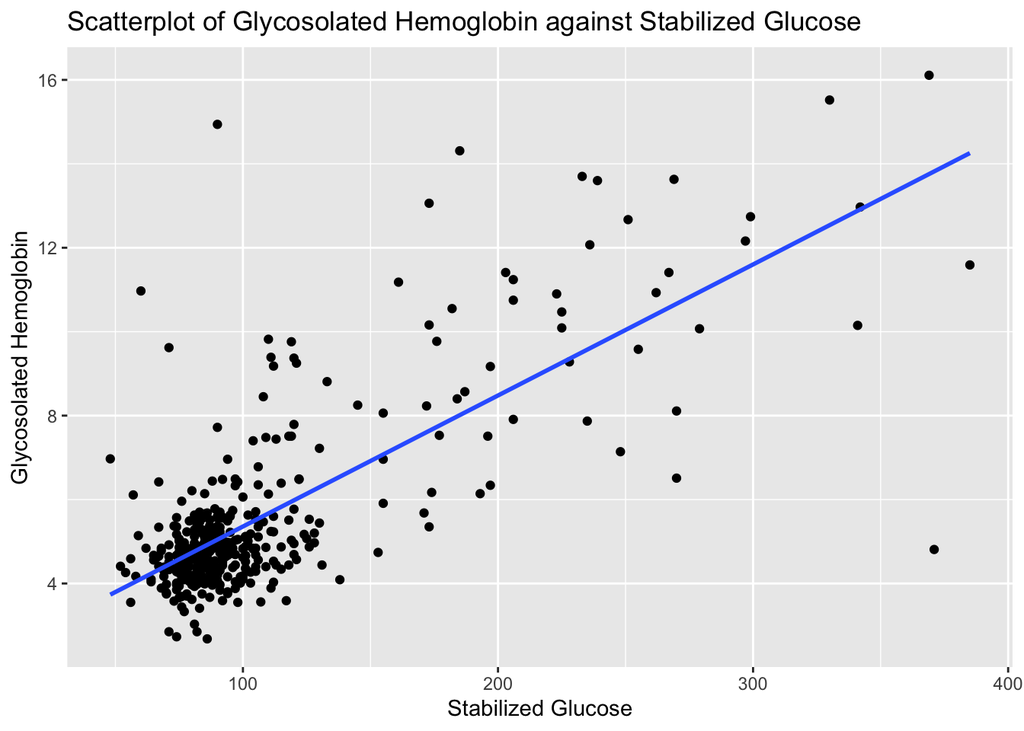

```r
#scatter plot to visualize variables with fitted regression line
ggplot(SLRdf, aes(x=stab.glu,y=glyhb))+
  geom_point()+
  geom_smooth(method = "lm", se=FALSE)+ #fit regression equation line to plot
  labs(x="Stabilized Glucose", y="Glycosolated Hemoglobin", title="Scatterplot of Glycosolated Hemoglobin against Stabilized Glucose")
```

#Observation:

There appears to be a positive linear relationship between the variables. However, there is clustering in the bottom left of the scatter plot.

```r
##Fit a simple linear regression model
result<-lm(glyhb~stab.glu, data=SLRdf)
summary(result)
```

```
##
## Call:
## lm(formula = glyhb ~ stab.glu, data = SLRdf)
##
## Residuals:
##     Min      1Q  Median      3Q     Max
## -9.0083 -0.6916 -0.1592  0.4255  9.8950
##
## Coefficients:
##             Estimate Std. Error t value Pr(>|t|)
## (Intercept) 2.235123   0.163877   13.64   <2e-16 ***
## stab.glu    0.031221   0.001376   22.69   <2e-16 ***
## ---
## Signif. codes:  0 '***' 0.001 '**' 0.01 '*' 0.05 '.' 0.1 ' ' 1
##
## Residual standard error: 1.464 on 401 degrees of freedom
## Multiple R-squared:  0.5622, Adjusted R-squared:  0.5611
## F-statistic:   515 on 1 and 401 DF,  p-value: < 2.2e-16
```

Estimated Regression Equation: y = 2.2351 + 0.0312x

#Interpretation:

# Model diagnostics

```r
##store fitted y & residuals
yhat<-result$fitted.values
res<-result$residuals

##add to data frame
SLRdf<-data.frame(SLRdf,yhat,res)
```

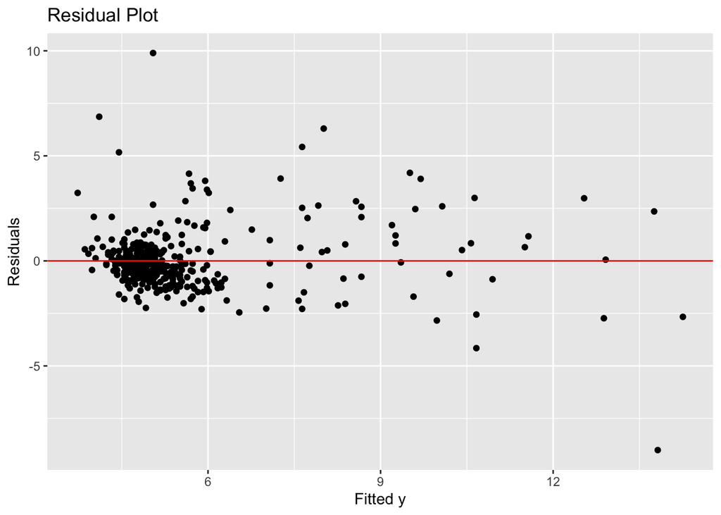

```r
##residual plot
ggplot(SLRdf, aes(x=yhat,y=res))+
  geom_point()+
  geom_hline(yintercept=0, color="red")+
  labs(x="Fitted y", y="Residuals", title="Residual Plot")
```

#Interpretation:

The error terms are clustered on the left side of the plot. This could indicate that the error terms do not have a constant variance, and that assumption 3 is not met. There does appear to be a linear pattern (seen in scatter plot), but there is clustering on the left side, which does not meet assumption 1, that the residuals are evenly scattered around the line without an apparent pattern. Also, the error terms appear to have a mean of zero, which does meet assumption 2. A transformation is needed to meet the assumptions.

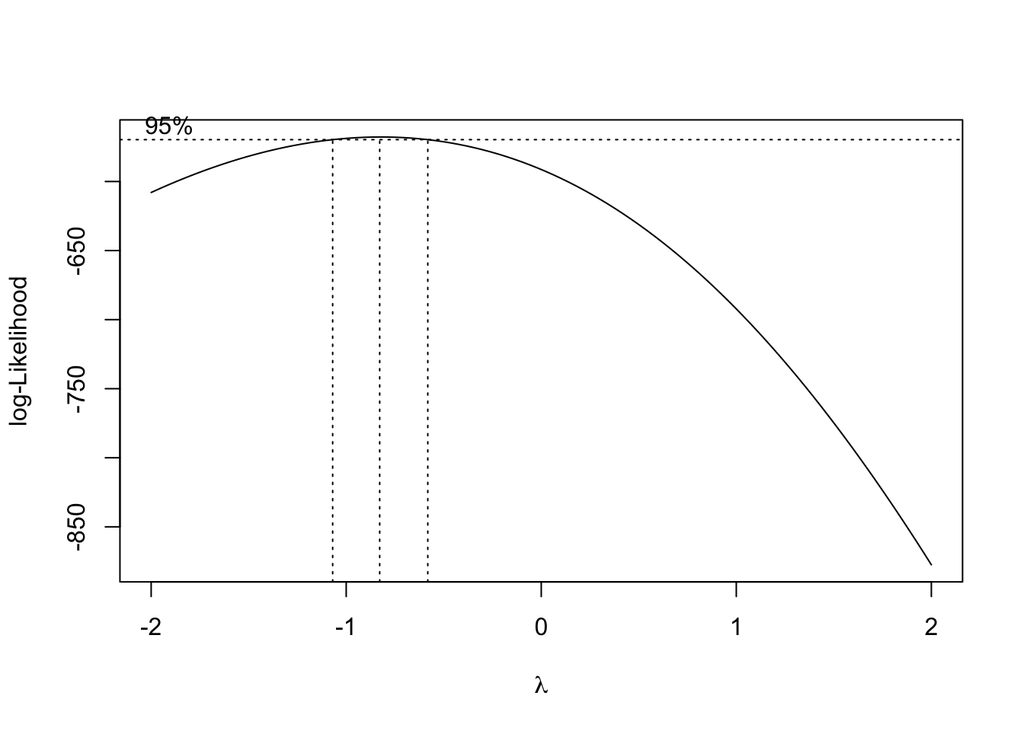

```r
#box cox plot
library(MASS) ##to use boxcox function
boxcox(result)
```

#Interpretation:

```r
##transform y and then regress ystar on x
ystar<-(SLRdf$glyhb)^-0.8
SLRdf<-data.frame(SLRdf,ystar)
result.ystar<-lm(ystar~stab.glu, data=SLRdf)

##store fitted y & residuals
yhat2<-result.ystar$fitted.values
res2<-result.ystar$residuals

##add to data frame
SLRdf<-data.frame(SLRdf,yhat2,res2)
```

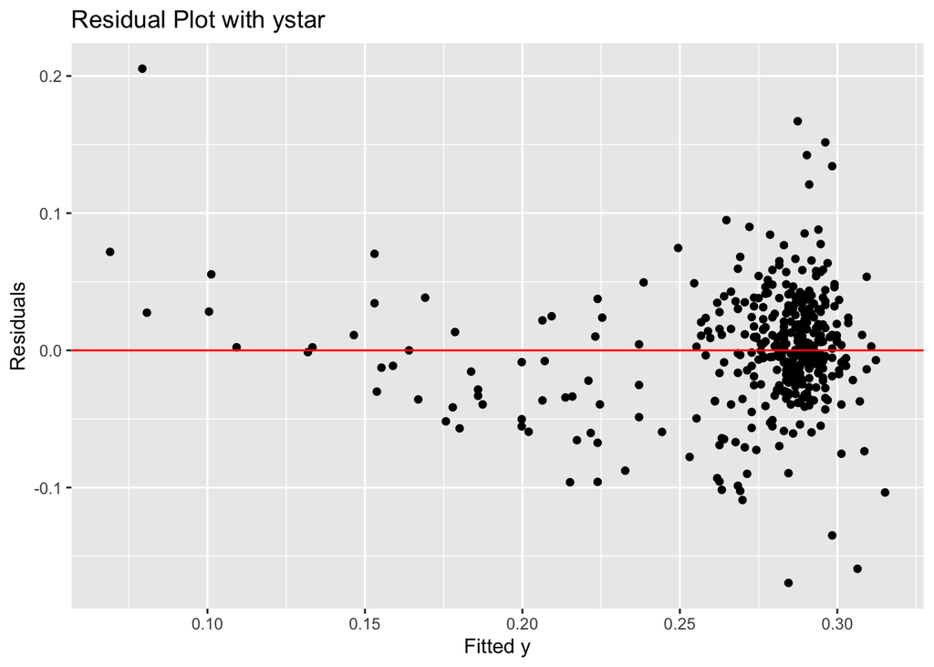

```r
##residual plot with ystar
ggplot(SLRdf, aes(x=yhat2,y=res2))+
  geom_point()+
  geom_hline(yintercept=0, color="red")+
  labs(x="Fitted y", y="Residuals", title="Residual Plot with ystar")
```

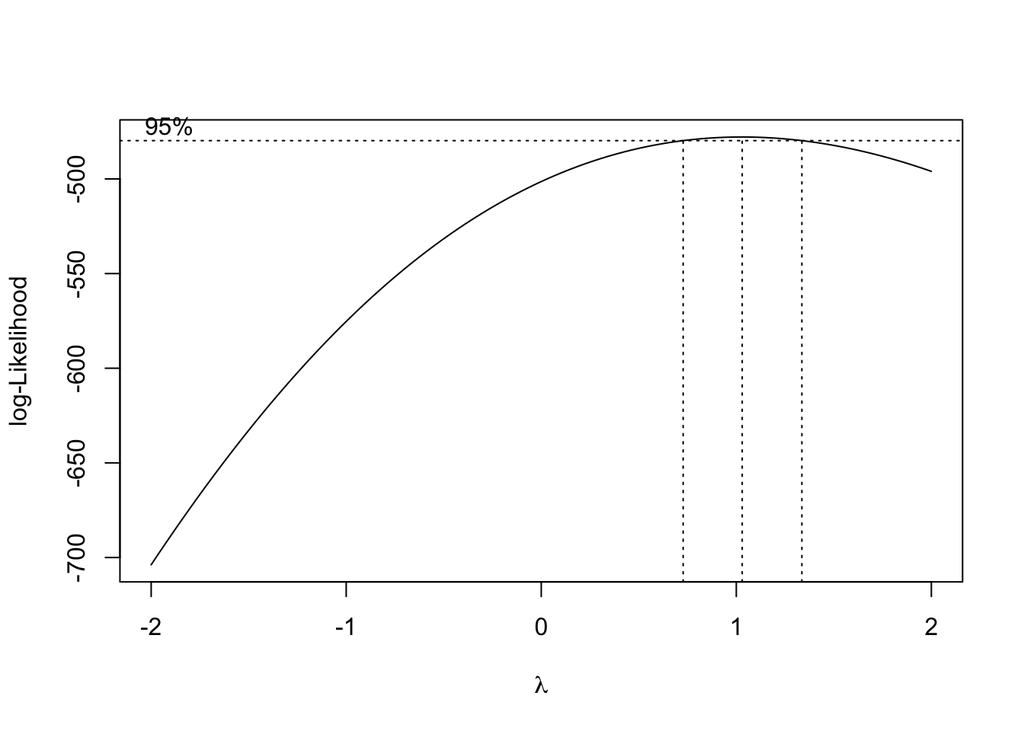

```r
boxcox(result.ystar)
```

#Interpretation:

```r
##transform y and then regress ystar on x
ystar<-(SLRdf$glyhb)^0.8
SLRdf<-data.frame(SLRdf,ystar)
result.ystar<-lm(ystar~stab.glu, data=SLRdf)

##store fitted y & residuals
yhat2<-result.ystar$fitted.values
res2<-result.ystar$residuals

##add to data frame
SLRdf<-data.frame(SLRdf,yhat2,res2)
```

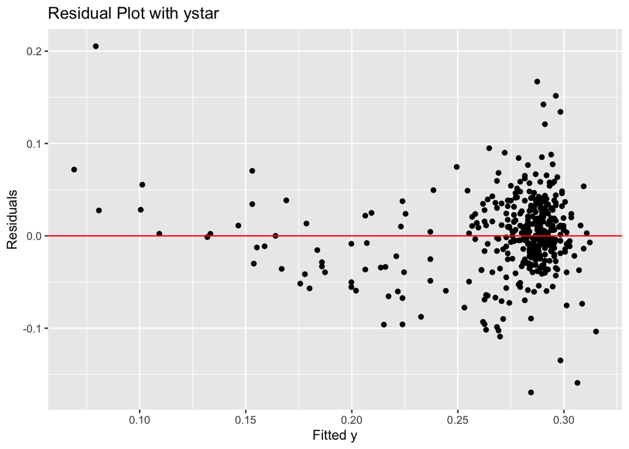

```r
##residual plot with ystar
ggplot(SLRdf, aes(x=yhat2,y=res2))+
  geom_point()+
  geom_hline(yintercept=0, color="red")+
  labs(x="Fitted y", y="Residuals", title="Residual Plot with ystar")
```

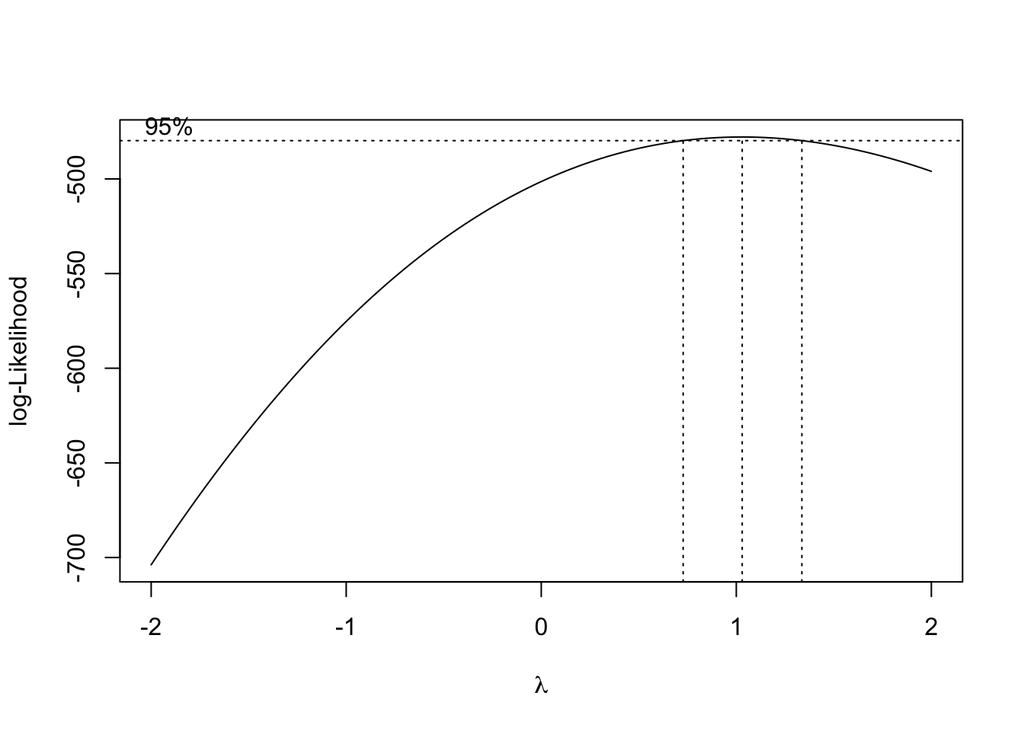

```r
boxcox(result.ystar)
```

#Interpretation:

#Check other assumptions

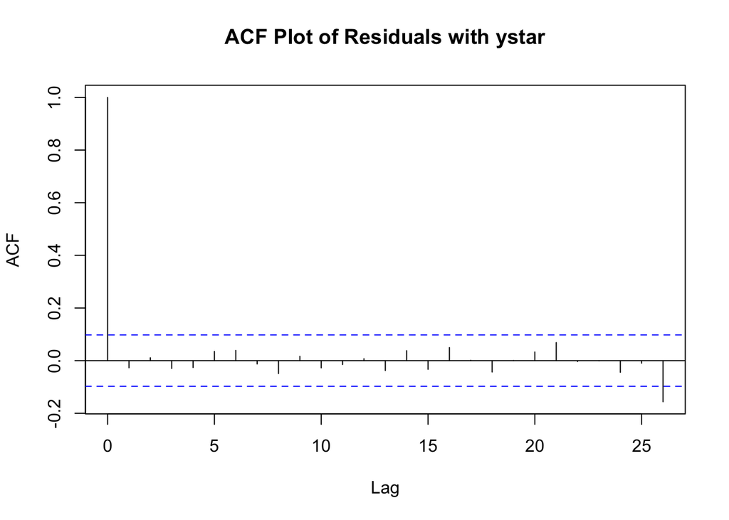

```r
#ACF plot of residuals
acf(res2, main="ACF Plot of Residuals with ystar")
```

#Interpretation:

The ACF plot checks assumption 4, that the error terms are uncorrelated and independed. The assumption is nearly met, because the vertical lines are within the horizontal blue lines. However, one line is not within the blue zone.

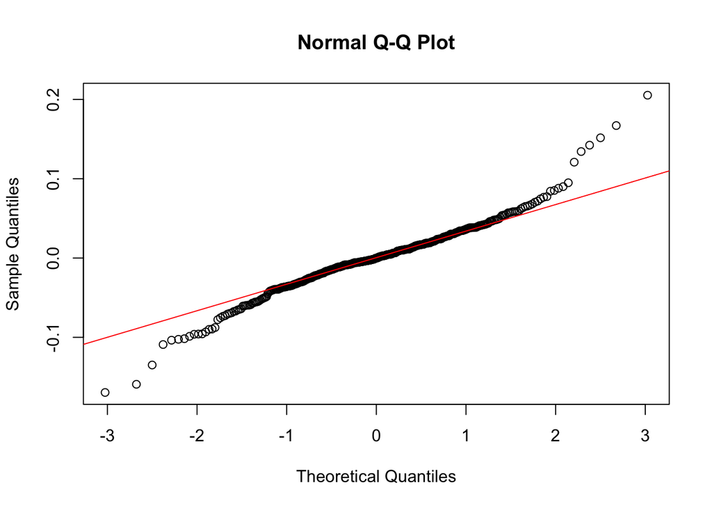

```r
#QQ plot of residuals
qqnorm(res2)
qqline(res2, col="red")
```

#Interpretation:

```r
result.ystar
```

```
##
## Call:
## lm(formula = ystar ~ stab.glu, data = SLRdf)
##
## Coefficients:
## (Intercept)     stab.glu
##   0.3502098   -0.0007302
```

```r
#correlation b/w glycosolated hemoglobin and stabilized glucose
cor(SLRdf$glyhb, SLRdf$stab.glu)
```

```
## [1] 0.749824
```

#Interpretation:

There is a strong positive relationship between Glycosolated Hemoglobin and Stabilized Glucose, because 0.749824 is fairly close to 1.

```r
#average of residuals
mean(result$residuals)
```

```
## [1] 1.399475e-17
```

#Interpretation:

The average value of all the residuals is 1.399475e-17. This suggests that the average data point is above, but very close the fitted line, because 1.399475e-17 is very close to 0. On average, the line appears to fit the data well.

```r
#ANOVA table

anova.tab<-anova(result)
anova.tab
```

```
## Analysis of Variance Table
##
## Response: glyhb
##            Df  Sum Sq Mean Sq F value    Pr(>F)
## stab.glu    1 1103.92 1103.92  515.02 < 2.2e-16 ***
## Residuals 401  859.52    2.14
## ---
## Signif. codes:  0 '***' 0.001 '**' 0.01 '*' 0.05 '.' 0.1 ' ' 1
```

```r
#calculate SST
SST<-sum(anova.tab$"Sum Sq")
SST
```

```
## [1] 1963.443
```

```r
#calculate R2
anova.tab$"Sum Sq"[1]/SST
```

```
## [1] 0.562236
```

#Hypothesis Test: H0: B1 = 0; Ha: B1 ≠ 0

- H0, the null hypothesis, suggests that there is no evidence of a linear relationship between Glycosolated Hemoglobin and Stabilized Glucose. (Regression line would be flat).
- Ha, the alternative hypothesis, suggests that there is evidence of a linear relationship between Glycosolated Hemoglobin and Stabilized Glucose. (Regression line would not be flat).

p-value = 2.2e-16

Based on the Anova F test for this SLR, we reject the null hypothesis and conclude that there is a linear relationship between Glycosolated Hemoglobin and Stabilized Glucose. The p-value is very low, at 2.2e-16, less than any alpha, so it is unlikely that the slope of 0.031221 occurred by chance.

```r
##produce 95% CIs for all regression coefficients
confint(result,level = 0.95)
```

```
##                  2.5 %     97.5 %
## (Intercept) 1.91295711 2.55728892
## stab.glu    0.02851678 0.03392596
```

```r
#confidence interval for average glycosolated hemoglobin with a stabilized glucose level of 0.04
##to produce 95% CI for the mean response when x=0.04
##and the 95% PI for the response of an observation when x=0.04
newdata<-data.frame(stab.glu=0.04)
predict(result,newdata,level=0.95, interval="confidence") #newdata <- for what value of x do i want to make a prediction of y for
```

```
##        fit      lwr      upr
## 1 2.236372 1.914303 2.558441
```

```r
#For a prediction interval for average glycosolated hemoglobin with a stabilized glucose level of 0.04
predict(result,newdata,level=0.95, interval="prediction")
```

```
##        fit        lwr      upr
## 1 2.236372 -0.6597715 5.132515
```

The 95% confidence interval for average Glycosolated Hemoglobin with a Stabilized Glucose level of 0.04 is (1.914303 2.558441).

The prediction interval for average Glycosolated Hemoglobin with a Stabilized Glucose level of 0.04 with 95% confidence is (-0.6597715, 5.132515).